# Risk Factor Analysis

## Outcome Variable

**Outcome Variable:** haz

## Predictor Variables

**Intervention Variable:** month

**Adjustment Set:**

unadjusted

## Stratifying Variables

The analysis was stratified on these variable(s):

- agecat
- studyid
- country

## Data Summary

| agecat | studyid | country | month | n_cell | n | outcome_variable |
| --- | --- | --- | --- | --- | --- | --- |
| Birth | ki0047075b-MAL-ED | BANGLADESH | 1 | 21 | 231 | haz |
| Birth | ki0047075b-MAL-ED | BANGLADESH | 2 | 21 | 231 | haz |
| Birth | ki0047075b-MAL-ED | BANGLADESH | 3 | 26 | 231 | haz |
| Birth | ki0047075b-MAL-ED | BANGLADESH | 4 | 21 | 231 | haz |
| Birth | ki0047075b-MAL-ED | BANGLADESH | 5 | 17 | 231 | haz |
| Birth | ki0047075b-MAL-ED | BANGLADESH | 6 | 8 | 231 | haz |
| Birth | ki0047075b-MAL-ED | BANGLADESH | 7 | 13 | 231 | haz |
| Birth | ki0047075b-MAL-ED | BANGLADESH | 8 | 27 | 231 | haz |
| Birth | ki0047075b-MAL-ED | BANGLADESH | 9 | 18 | 231 | haz |
| Birth | ki0047075b-MAL-ED | BANGLADESH | 10 | 20 | 231 | haz |
| Birth | ki0047075b-MAL-ED | BANGLADESH | 11 | 13 | 231 | haz |
| Birth | ki0047075b-MAL-ED | BANGLADESH | 12 | 26 | 231 | haz |
| Birth | ki0047075b-MAL-ED | BRAZIL | 1 | 5 | 65 | haz |
| Birth | ki0047075b-MAL-ED | BRAZIL | 2 | 8 | 65 | haz |
| Birth | ki0047075b-MAL-ED | BRAZIL | 3 | 9 | 65 | haz |
| Birth | ki0047075b-MAL-ED | BRAZIL | 4 | 5 | 65 | haz |
| Birth | ki0047075b-MAL-ED | BRAZIL | 5 | 2 | 65 | haz |
| Birth | ki0047075b-MAL-ED | BRAZIL | 6 | 5 | 65 | haz |
| Birth | ki0047075b-MAL-ED | BRAZIL | 7 | 5 | 65 | haz |
| Birth | ki0047075b-MAL-ED | BRAZIL | 8 | 7 | 65 | haz |
| Birth | ki0047075b-MAL-ED | BRAZIL | 9 | 7 | 65 | haz |
| Birth | ki0047075b-MAL-ED | BRAZIL | 10 | 4 | 65 | haz |
| Birth | ki0047075b-MAL-ED | BRAZIL | 11 | 5 | 65 | haz |
| Birth | ki0047075b-MAL-ED | BRAZIL | 12 | 3 | 65 | haz |
| Birth | ki0047075b-MAL-ED | INDIA | 1 | 2 | 47 | haz |
| Birth | ki0047075b-MAL-ED | INDIA | 2 | 3 | 47 | haz |
| Birth | ki0047075b-MAL-ED | INDIA | 3 | 5 | 47 | haz |
| Birth | ki0047075b-MAL-ED | INDIA | 4 | 7 | 47 | haz |
| Birth | ki0047075b-MAL-ED | INDIA | 5 | 2 | 47 | haz |
| Birth | ki0047075b-MAL-ED | INDIA | 6 | 3 | 47 | haz |

[output cut: 774 more lines]

The following strata were considered:

- agecat: 24 months, studyid: ki0047075b-MAL-ED, country: BANGLADESH
- agecat: 24 months, studyid: ki0047075b-MAL-ED, country: BRAZIL
- agecat: 24 months, studyid: ki0047075b-MAL-ED, country: INDIA
- agecat: 24 months, studyid: ki0047075b-MAL-ED, country: NEPAL
- agecat: 24 months, studyid: ki0047075b-MAL-ED, country: PERU
- agecat: 24 months, studyid: ki0047075b-MAL-ED, country: SOUTH AFRICA
- agecat: 24 months, studyid: ki0047075b-MAL-ED, country: TANZANIA, UNITED REPUBLIC OF
- agecat: 24 months, studyid: ki1000108-CMC-V-BCS-2002, country: INDIA
- agecat: 24 months, studyid: ki1000108-IRC, country: INDIA
- agecat: 24 months, studyid: ki1000109-EE, country: PAKISTAN
- agecat: 24 months, studyid: ki1017093-NIH-Birth, country: BANGLADESH
- agecat: 24 months, studyid: ki1066203-TanzaniaChild2, country: TANZANIA, UNITED REPUBLIC OF
- agecat: 24 months, studyid: ki1101329-Keneba, country: GAMBIA
- agecat: 24 months, studyid: ki1113344-GMS-Nepal, country: NEPAL
- agecat: 24 months, studyid: ki1114097-CMIN, country: BANGLADESH
- agecat: 24 months, studyid: ki1114097-CONTENT, country: PERU
- agecat: 24 months, studyid: ki1119695-PROBIT, country: BELARUS
- agecat: 24 months, studyid: ki1126311-ZVITAMBO, country: ZIMBABWE
- agecat: 24 months, studyid: ki1148112-LCNI-5, country: MALAWI
- agecat: 24 months, studyid: kiGH5241-JiVitA-3, country: BANGLADESH
- agecat: 24 months, studyid: kiGH5241-JiVitA-4, country: BANGLADESH
- agecat: 6 months, studyid: ki0047075b-MAL-ED, country: BANGLADESH
- agecat: 6 months, studyid: ki0047075b-MAL-ED, country: BRAZIL
- agecat: 6 months, studyid: ki0047075b-MAL-ED, country: INDIA
- agecat: 6 months, studyid: ki0047075b-MAL-ED, country: NEPAL
- agecat: 6 months, studyid: ki0047075b-MAL-ED, country: PERU
- agecat: 6 months, studyid: ki0047075b-MAL-ED, country: SOUTH AFRICA
- agecat: 6 months, studyid: ki0047075b-MAL-ED, country: TANZANIA, UNITED REPUBLIC OF
- agecat: 6 months, studyid: ki1000108-CMC-V-BCS-2002, country: INDIA
- agecat: 6 months, studyid: ki1000108-IRC, country: INDIA
- agecat: 6 months, studyid: ki1000109-EE, country: PAKISTAN
- agecat: 6 months, studyid: ki1000109-ResPak, country: PAKISTAN
- agecat: 6 months, studyid: ki1000304b-SAS-CompFeed, country: INDIA
- agecat: 6 months, studyid: ki1000304b-SAS-FoodSuppl, country: INDIA
- agecat: 6 months, studyid: ki1017093-NIH-Birth, country: BANGLADESH
- agecat: 6 months, studyid: ki1066203-TanzaniaChild2, country: TANZANIA, UNITED REPUBLIC OF
- agecat: 6 months, studyid: ki1101329-Keneba, country: GAMBIA
- agecat: 6 months, studyid: ki1112895-Guatemala BSC, country: GUATEMALA
- agecat: 6 months, studyid: ki1113344-GMS-Nepal, country: NEPAL
- agecat: 6 months, studyid: ki1114097-CMIN, country: BANGLADESH
- agecat: 6 months, studyid: ki1114097-CONTENT, country: PERU
- agecat: 6 months, studyid: ki1119695-PROBIT, country: BELARUS
- agecat: 6 months, studyid: ki1126311-ZVITAMBO, country: ZIMBABWE
- agecat: 6 months, studyid: ki1148112-LCNI-5, country: MALAWI
- agecat: 6 months, studyid: kiGH5241-JiVitA-3, country: BANGLADESH
- agecat: 6 months, studyid: kiGH5241-JiVitA-4, country: BANGLADESH
- agecat: Birth, studyid: ki0047075b-MAL-ED, country: BANGLADESH
- agecat: Birth, studyid: ki0047075b-MAL-ED, country: BRAZIL
- agecat: Birth, studyid: ki0047075b-MAL-ED, country: INDIA
- agecat: Birth, studyid: ki0047075b-MAL-ED, country: NEPAL
- agecat: Birth, studyid: ki0047075b-MAL-ED, country: PERU
- agecat: Birth, studyid: ki0047075b-MAL-ED, country: SOUTH AFRICA
- agecat: Birth, studyid: ki0047075b-MAL-ED, country: TANZANIA, UNITED REPUBLIC OF
- agecat: Birth, studyid: ki1000108-CMC-V-BCS-2002, country: INDIA
- agecat: Birth, studyid: ki1000108-IRC, country: INDIA
- agecat: Birth, studyid: ki1000109-EE, country: PAKISTAN
- agecat: Birth, studyid: ki1000109-ResPak, country: PAKISTAN
- agecat: Birth, studyid: ki1000304b-SAS-CompFeed, country: INDIA
- agecat: Birth, studyid: ki1017093-NIH-Birth, country: BANGLADESH
- agecat: Birth, studyid: ki1101329-Keneba, country: GAMBIA
- agecat: Birth, studyid: ki1113344-GMS-Nepal, country: NEPAL
- agecat: Birth, studyid: ki1114097-CMIN, country: BANGLADESH
- agecat: Birth, studyid: ki1114097-CONTENT, country: PERU
- agecat: Birth, studyid: ki1119695-PROBIT, country: BELARUS
- agecat: Birth, studyid: ki1126311-ZVITAMBO, country: ZIMBABWE
- agecat: Birth, studyid: kiGH5241-JiVitA-3, country: BANGLADESH
- agecat: Birth, studyid: kiGH5241-JiVitA-4, country: BANGLADESH

### Dropped Strata

Some strata were dropped due to rare outcomes:

- agecat: Birth, studyid: ki0047075b-MAL-ED, country: BRAZIL
- agecat: Birth, studyid: ki0047075b-MAL-ED, country: INDIA
- agecat: Birth, studyid: ki0047075b-MAL-ED, country: NEPAL
- agecat: Birth, studyid: ki0047075b-MAL-ED, country: SOUTH AFRICA
- agecat: Birth, studyid: ki0047075b-MAL-ED, country: TANZANIA, UNITED REPUBLIC OF
- agecat: Birth, studyid: ki1000108-CMC-V-BCS-2002, country: INDIA
- agecat: Birth, studyid: ki1000109-EE, country: PAKISTAN
- agecat: Birth, studyid: ki1000109-ResPak, country: PAKISTAN
- agecat: Birth, studyid: ki1113344-GMS-Nepal, country: NEPAL
- agecat: Birth, studyid: ki1114097-CMIN, country: BANGLADESH
- agecat: Birth, studyid: ki1114097-CONTENT, country: PERU
- agecat: Birth, studyid: kiGH5241-JiVitA-4, country: BANGLADESH
- agecat: 6 months, studyid: ki1000109-EE, country: PAKISTAN
- agecat: 6 months, studyid: ki1000109-ResPak, country: PAKISTAN
- agecat: 6 months, studyid: ki1000304b-SAS-FoodSuppl, country: INDIA
- agecat: 6 months, studyid: ki1113344-GMS-Nepal, country: NEPAL
- agecat: 6 months, studyid: ki1114097-CMIN, country: BANGLADESH
- agecat: 24 months, studyid: ki1000109-EE, country: PAKISTAN
- agecat: 24 months, studyid: ki1066203-TanzaniaChild2, country: TANZANIA, UNITED REPUBLIC OF
- agecat: 24 months, studyid: ki1113344-GMS-Nepal, country: NEPAL
- agecat: 24 months, studyid: ki1114097-CMIN, country: BANGLADESH
- agecat: 24 months, studyid: ki1114097-CONTENT, country: PERU

## Methods Detail

We’re interested in the causal parameters $E[Y_a]$ for all values of $a \in \mathcal{A}$. These parameters represent the mean outcome if, possibly contrary to fact, we intervened to set all units to have $A=a$. Under the randomization and positivity assumptions, these are identified by the statistical parameters $\psi_a=E_W[E_{Y|A,W}(Y|A=a,W)]$. In addition, we’re interested in the mean of $Y$, $E[Y]$ under no intervention (the observed mean). We will estimate these parameters by using SuperLearner to fit the relevant likelihood factors – $E_{Y|A,W}(Y|A=a,W)$ and $p(A=a|W)$, and then updating our likelihood fit using a joint TMLE.

For unadjusted analyses ($W=\{\}$), initial likelihoods were estimated using Lrnr_glm to estimate the simple $E(Y|A)$ and Lrnr_mean to estimate $p(A)$. For adjusted analyses, a small library containing Lrnr_glmnet, Lrnr_xgboost, and Lrnr_mean was used.

Having estimated these parameters, we will then use the delta method to estimate relative risks and attributable risks relative to a prespecified baseline level of $A$.

# Results Detail

## Results Plots

[figure not shown]

[figure not shown]

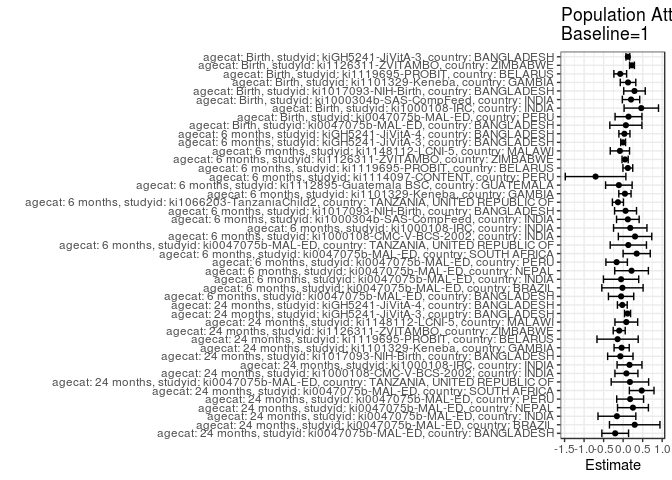

## Results Table

### Parameter: TSM

| agecat | studyid | country | intervention_level | baseline_level | estimate | ci_lower | ci_upper |
| --- | --- | --- | --- | --- | --- | --- | --- |
| Birth | ki0047075b-MAL-ED | BANGLADESH | 1 | NA | -1.1885714 | -1.6180992 | -0.7590437 |
| Birth | ki0047075b-MAL-ED | BANGLADESH | 2 | NA | -1.3861905 | -1.8437395 | -0.9286414 |
| Birth | ki0047075b-MAL-ED | BANGLADESH | 3 | NA | -1.1592308 | -1.5228053 | -0.7956562 |
| Birth | ki0047075b-MAL-ED | BANGLADESH | 4 | NA | -0.7347619 | -1.1421886 | -0.3273352 |
| Birth | ki0047075b-MAL-ED | BANGLADESH | 5 | NA | -1.3058824 | -1.8008814 | -0.8108833 |
| Birth | ki0047075b-MAL-ED | BANGLADESH | 6 | NA | -1.3650000 | -2.1871543 | -0.5428457 |
| Birth | ki0047075b-MAL-ED | BANGLADESH | 7 | NA | -1.1138462 | -1.7428633 | -0.4848290 |
| Birth | ki0047075b-MAL-ED | BANGLADESH | 8 | NA | -1.2559259 | -1.6760825 | -0.8357694 |
| Birth | ki0047075b-MAL-ED | BANGLADESH | 9 | NA | -1.1872222 | -1.6895543 | -0.6848901 |
| Birth | ki0047075b-MAL-ED | BANGLADESH | 10 | NA | -1.0980000 | -1.5303574 | -0.6656426 |
| Birth | ki0047075b-MAL-ED | BANGLADESH | 11 | NA | -0.7915385 | -1.2756515 | -0.3074254 |
| Birth | ki0047075b-MAL-ED | BANGLADESH | 12 | NA | -0.9042308 | -1.2645004 | -0.5439611 |
| Birth | ki0047075b-MAL-ED | PERU | 1 | NA | -1.0204000 | -1.3856198 | -0.6551802 |
| Birth | ki0047075b-MAL-ED | PERU | 2 | NA | -1.0657143 | -1.4593131 | -0.6721154 |
| Birth | ki0047075b-MAL-ED | PERU | 3 | NA | -1.1100000 | -1.4844154 | -0.7355846 |
| Birth | ki0047075b-MAL-ED | PERU | 4 | NA | -0.6571429 | -1.2495842 | -0.0647015 |
| Birth | ki0047075b-MAL-ED | PERU | 5 | NA | -0.9289474 | -1.3517521 | -0.5061427 |
| Birth | ki0047075b-MAL-ED | PERU | 6 | NA | -0.2973333 | -0.7382816 | 0.1436149 |
| Birth | ki0047075b-MAL-ED | PERU | 7 | NA | -0.9195000 | -1.3267010 | -0.5122990 |
| Birth | ki0047075b-MAL-ED | PERU | 8 | NA | -0.7200000 | -1.1074636 | -0.3325364 |
| Birth | ki0047075b-MAL-ED | PERU | 9 | NA | -0.6330000 | -0.8903534 | -0.3756466 |
| Birth | ki0047075b-MAL-ED | PERU | 10 | NA | -0.6765000 | -0.9309254 | -0.4220746 |
| Birth | ki0047075b-MAL-ED | PERU | 11 | NA | -1.1696552 | -1.5106046 | -0.8287058 |
| Birth | ki0047075b-MAL-ED | PERU | 12 | NA | -0.9733333 | -1.4894073 | -0.4572594 |
| Birth | ki1000108-IRC | INDIA | 1 | NA | -0.7729412 | -1.2245057 | -0.3213766 |
| Birth | ki1000108-IRC | INDIA | 2 | NA | -0.3068000 | -1.0300491 | 0.4164491 |
| Birth | ki1000108-IRC | INDIA | 3 | NA | -0.2288889 | -0.7355333 | 0.2777555 |
| Birth | ki1000108-IRC | INDIA | 4 | NA | 0.0854545 | -0.6118832 | 0.7827923 |
| Birth | ki1000108-IRC | INDIA | 5 | NA | 0.3619048 | -0.4153839 | 1.1391935 |
| Birth | ki1000108-IRC | INDIA | 6 | NA | 0.0400000 | -0.6638078 | 0.7438078 |

[output cut: 510 more lines]

### Parameter: E(Y)

| agecat | studyid | country | intervention_level | baseline_level | estimate | ci_lower | ci_upper |
| --- | --- | --- | --- | --- | --- | --- | --- |
| Birth | ki0047075b-MAL-ED | BANGLADESH | NA | NA | -1.1180952 | -1.2525408 | -0.9836496 |
| Birth | ki0047075b-MAL-ED | PERU | NA | NA | -0.8827897 | -1.0001058 | -0.7654736 |
| Birth | ki1000108-IRC | INDIA | NA | NA | -0.3080412 | -0.4687931 | -0.1472894 |
| Birth | ki1000304b-SAS-CompFeed | INDIA | NA | NA | -1.4314217 | -1.5099245 | -1.3529189 |
| Birth | ki1017093-NIH-Birth | BANGLADESH | NA | NA | -0.9310197 | -1.0197391 | -0.8423003 |
| Birth | ki1101329-Keneba | GAMBIA | NA | NA | 0.0308036 | -0.0328378 | 0.0944451 |
| Birth | ki1119695-PROBIT | BELARUS | NA | NA | 1.3269446 | 1.1683850 | 1.4855041 |
| Birth | ki1126311-ZVITAMBO | ZIMBABWE | NA | NA | -0.5002724 | -0.5208163 | -0.4797285 |
| Birth | kiGH5241-JiVitA-3 | BANGLADESH | NA | NA | -1.5894148 | -1.6086362 | -1.5701935 |
| 6 months | ki0047075b-MAL-ED | BANGLADESH | NA | NA | -1.2049931 | -1.3222136 | -1.0877726 |
| 6 months | ki0047075b-MAL-ED | BRAZIL | NA | NA | 0.0475758 | -0.0963508 | 0.1915023 |
| 6 months | ki0047075b-MAL-ED | INDIA | NA | NA | -1.2115254 | -1.3298727 | -1.0931782 |
| 6 months | ki0047075b-MAL-ED | NEPAL | NA | NA | -0.5615819 | -0.6741832 | -0.4489807 |
| 6 months | ki0047075b-MAL-ED | PERU | NA | NA | -1.3236661 | -1.4316775 | -1.2156546 |
| 6 months | ki0047075b-MAL-ED | SOUTH AFRICA | NA | NA | -1.0633202 | -1.1909180 | -0.9357224 |
| 6 months | ki0047075b-MAL-ED | TANZANIA, UNITED REPUBLIC OF | NA | NA | -1.3687449 | -1.4907629 | -1.2467270 |
| 6 months | ki1000108-CMC-V-BCS-2002 | INDIA | NA | NA | -1.4234508 | -1.5645974 | -1.2823042 |
| 6 months | ki1000108-IRC | INDIA | NA | NA | -1.2344062 | -1.3658524 | -1.1029600 |
| 6 months | ki1000304b-SAS-CompFeed | INDIA | NA | NA | -1.4018563 | -1.4810585 | -1.3226541 |
| 6 months | ki1017093-NIH-Birth | BANGLADESH | NA | NA | -1.4073821 | -1.4960598 | -1.3187043 |
| 6 months | ki1066203-TanzaniaChild2 | TANZANIA, UNITED REPUBLIC OF | NA | NA | -0.5434389 | -0.5924056 | -0.4944722 |
| 6 months | ki1101329-Keneba | GAMBIA | NA | NA | -0.9041369 | -0.9513363 | -0.8569376 |
| 6 months | ki1112895-Guatemala BSC | GUATEMALA | NA | NA | -1.5619008 | -1.6727702 | -1.4510313 |
| 6 months | ki1114097-CONTENT | PERU | NA | NA | -0.3139217 | -0.4868486 | -0.1409948 |
| 6 months | ki1119695-PROBIT | BELARUS | NA | NA | 0.1069986 | 0.0122286 | 0.2017686 |
| 6 months | ki1126311-ZVITAMBO | ZIMBABWE | NA | NA | -0.8679450 | -0.8935071 | -0.8423828 |
| 6 months | ki1148112-LCNI-5 | MALAWI | NA | NA | -1.6601907 | -1.7297701 | -1.5906113 |
| 6 months | kiGH5241-JiVitA-3 | BANGLADESH | NA | NA | -1.3130932 | -1.3362359 | -1.2899505 |
| 6 months | kiGH5241-JiVitA-4 | BANGLADESH | NA | NA | -1.3447940 | -1.3820261 | -1.3075620 |
| 24 months | ki0047075b-MAL-ED | BANGLADESH | NA | NA | -1.9783962 | -2.1050210 | -1.8517715 |
| 24 months | ki0047075b-MAL-ED | BRAZIL | NA | NA | 0.0061144 | -0.1625850 | 0.1748138 |
| 24 months | ki0047075b-MAL-ED | INDIA | NA | NA | -1.8861894 | -2.0110006 | -1.7613783 |
| 24 months | ki0047075b-MAL-ED | NEPAL | NA | NA | -1.3075877 | -1.4270718 | -1.1881037 |
| 24 months | ki0047075b-MAL-ED | PERU | NA | NA | -1.7524710 | -1.8736426 | -1.6312994 |
| 24 months | ki0047075b-MAL-ED | SOUTH AFRICA | NA | NA | -1.6450595 | -1.7797240 | -1.5103950 |
| 24 months | ki0047075b-MAL-ED | TANZANIA, UNITED REPUBLIC OF | NA | NA | -2.6455607 | -2.7807256 | -2.5103959 |
| 24 months | ki1000108-CMC-V-BCS-2002 | INDIA | NA | NA | -2.5588679 | -2.6583730 | -2.4593629 |
| 24 months | ki1000108-IRC | INDIA | NA | NA | -1.7987775 | -1.8923914 | -1.7051636 |
| 24 months | ki1017093-NIH-Birth | BANGLADESH | NA | NA | -2.2190579 | -2.3217459 | -2.1163699 |
| 24 months | ki1101329-Keneba | GAMBIA | NA | NA | -1.5774356 | -1.6272400 | -1.5276311 |
| 24 months | ki1119695-PROBIT | BELARUS | NA | NA | -0.1314048 | -0.4282725 | 0.1654630 |
| 24 months | ki1126311-ZVITAMBO | ZIMBABWE | NA | NA | -1.6055701 | -1.6625562 | -1.5485840 |
| 24 months | ki1148112-LCNI-5 | MALAWI | NA | NA | -1.8861485 | -1.9671802 | -1.8051169 |
| 24 months | kiGH5241-JiVitA-3 | BANGLADESH | NA | NA | -2.0136481 | -2.0413552 | -1.9859409 |
| 24 months | kiGH5241-JiVitA-4 | BANGLADESH | NA | NA | -1.7807218 | -1.8162478 | -1.7451958 |

### Parameter: ATE

| agecat | studyid | country | intervention_level | baseline_level | estimate | ci_lower | ci_upper |
| --- | --- | --- | --- | --- | --- | --- | --- |
| Birth | ki0047075b-MAL-ED | BANGLADESH | 1 | 1 | 0.0000000 | 0.0000000 | 0.0000000 |
| Birth | ki0047075b-MAL-ED | BANGLADESH | 2 | 1 | -0.1976190 | -0.8251899 | 0.4299518 |
| Birth | ki0047075b-MAL-ED | BANGLADESH | 3 | 1 | 0.0293407 | -0.5334031 | 0.5920844 |
| Birth | ki0047075b-MAL-ED | BANGLADESH | 4 | 1 | 0.4538095 | -0.1382129 | 1.0458320 |
| Birth | ki0047075b-MAL-ED | BANGLADESH | 5 | 1 | -0.1173109 | -0.7726873 | 0.5380654 |
| Birth | ki0047075b-MAL-ED | BANGLADESH | 6 | 1 | -0.1764286 | -1.1040232 | 0.7511661 |
| Birth | ki0047075b-MAL-ED | BANGLADESH | 7 | 1 | 0.0747253 | -0.6869549 | 0.8364054 |
| Birth | ki0047075b-MAL-ED | BANGLADESH | 8 | 1 | -0.0673545 | -0.6682085 | 0.5334995 |
| Birth | ki0047075b-MAL-ED | BANGLADESH | 9 | 1 | 0.0013492 | -0.6595832 | 0.6622816 |
| Birth | ki0047075b-MAL-ED | BANGLADESH | 10 | 1 | 0.0905714 | -0.5188767 | 0.7000195 |
| Birth | ki0047075b-MAL-ED | BANGLADESH | 11 | 1 | 0.3970330 | -0.2501606 | 1.0442265 |
| Birth | ki0047075b-MAL-ED | BANGLADESH | 12 | 1 | 0.2843407 | -0.2762735 | 0.8449549 |
| Birth | ki0047075b-MAL-ED | PERU | 1 | 1 | 0.0000000 | 0.0000000 | 0.0000000 |
| Birth | ki0047075b-MAL-ED | PERU | 2 | 1 | -0.0453143 | -0.5822552 | 0.4916266 |
| Birth | ki0047075b-MAL-ED | PERU | 3 | 1 | -0.0896000 | -0.6126415 | 0.4334415 |
| Birth | ki0047075b-MAL-ED | PERU | 4 | 1 | 0.3632571 | -0.3327114 | 1.0592257 |
| Birth | ki0047075b-MAL-ED | PERU | 5 | 1 | 0.0914526 | -0.4672506 | 0.6501559 |
| Birth | ki0047075b-MAL-ED | PERU | 6 | 1 | 0.7230667 | 0.1505102 | 1.2956231 |
| Birth | ki0047075b-MAL-ED | PERU | 7 | 1 | 0.1009000 | -0.4460901 | 0.6478901 |
| Birth | ki0047075b-MAL-ED | PERU | 8 | 1 | 0.3004000 | -0.2320599 | 0.8328599 |
| Birth | ki0047075b-MAL-ED | PERU | 9 | 1 | 0.3874000 | -0.0593844 | 0.8341844 |
| Birth | ki0047075b-MAL-ED | PERU | 10 | 1 | 0.3439000 | -0.1012042 | 0.7890042 |
| Birth | ki0047075b-MAL-ED | PERU | 11 | 1 | -0.1492552 | -0.6488870 | 0.3503767 |
| Birth | ki0047075b-MAL-ED | PERU | 12 | 1 | 0.0470667 | -0.5851658 | 0.6792991 |
| Birth | ki1000108-IRC | INDIA | 1 | 1 | 0.0000000 | 0.0000000 | 0.0000000 |
| Birth | ki1000108-IRC | INDIA | 2 | 1 | 0.4661412 | -0.3865016 | 1.3187840 |
| Birth | ki1000108-IRC | INDIA | 3 | 1 | 0.5440523 | -0.1346222 | 1.2227268 |
| Birth | ki1000108-IRC | INDIA | 4 | 1 | 0.8583957 | 0.0276187 | 1.6891727 |
| Birth | ki1000108-IRC | INDIA | 5 | 1 | 1.1348459 | 0.2359086 | 2.0337832 |
| Birth | ki1000108-IRC | INDIA | 6 | 1 | 0.8129412 | -0.0232741 | 1.6491564 |

[output cut: 510 more lines]

### Parameter: PAR

| agecat | studyid | country | intervention_level | baseline_level | estimate | ci_lower | ci_upper |
| --- | --- | --- | --- | --- | --- | --- | --- |
| Birth | ki0047075b-MAL-ED | BANGLADESH | 1 | NA | 0.0704762 | -0.3406507 | 0.4816031 |
| Birth | ki0047075b-MAL-ED | PERU | 1 | NA | 0.1376103 | -0.2066644 | 0.4818850 |
| Birth | ki1000108-IRC | INDIA | 1 | NA | 0.4648999 | 0.0244288 | 0.9053711 |
| Birth | ki1000304b-SAS-CompFeed | INDIA | 1 | NA | 0.2017490 | -0.0211633 | 0.4246614 |
| Birth | ki1017093-NIH-Birth | BANGLADESH | 1 | NA | 0.2906726 | 0.0151712 | 0.5661739 |
| Birth | ki1101329-Keneba | GAMBIA | 1 | NA | 0.1253688 | -0.0732281 | 0.3239658 |
| Birth | ki1119695-PROBIT | BELARUS | 1 | NA | -0.0739693 | -0.2372087 | 0.0892701 |
| Birth | ki1126311-ZVITAMBO | ZIMBABWE | 1 | NA | 0.2267846 | 0.1647186 | 0.2888507 |
| Birth | kiGH5241-JiVitA-3 | BANGLADESH | 1 | NA | 0.1209355 | 0.0719621 | 0.1699090 |
| 6 months | ki0047075b-MAL-ED | BANGLADESH | 1 | NA | -0.0522738 | -0.3762156 | 0.2716681 |
| 6 months | ki0047075b-MAL-ED | BRAZIL | 1 | NA | -0.0175433 | -0.5458886 | 0.5108021 |
| 6 months | ki0047075b-MAL-ED | INDIA | 1 | NA | -0.0529699 | -0.5046682 | 0.3987285 |
| 6 months | ki0047075b-MAL-ED | NEPAL | 1 | NA | 0.2154181 | -0.2155511 | 0.6463872 |
| 6 months | ki0047075b-MAL-ED | PERU | 1 | NA | -0.1664438 | -0.4415106 | 0.1086229 |
| 6 months | ki0047075b-MAL-ED | SOUTH AFRICA | 1 | NA | 0.3467840 | -0.0007755 | 0.6943434 |
| 6 months | ki0047075b-MAL-ED | TANZANIA, UNITED REPUBLIC OF | 1 | NA | 0.1329217 | -0.3314612 | 0.5973046 |
| 6 months | ki1000108-CMC-V-BCS-2002 | INDIA | 1 | NA | 0.3054183 | -0.1226384 | 0.7334749 |
| 6 months | ki1000108-IRC | INDIA | 1 | NA | 0.1821176 | -0.2455357 | 0.6097709 |
| 6 months | ki1000304b-SAS-CompFeed | INDIA | 1 | NA | 0.1204967 | -0.1687735 | 0.4097668 |
| 6 months | ki1017093-NIH-Birth | BANGLADESH | 1 | NA | 0.0619179 | -0.2188523 | 0.3426881 |
| 6 months | ki1066203-TanzaniaChild2 | TANZANIA, UNITED REPUBLIC OF | 1 | NA | -0.1333300 | -0.2752736 | 0.0086136 |
| 6 months | ki1101329-Keneba | GAMBIA | 1 | NA | 0.0460352 | -0.1107255 | 0.2027959 |
| 6 months | ki1112895-Guatemala BSC | GUATEMALA | 1 | NA | -0.1095860 | -0.4491361 | 0.2299642 |
| 6 months | ki1114097-CONTENT | PERU | 1 | NA | -0.7059773 | -1.4819268 | 0.0699723 |
| 6 months | ki1119695-PROBIT | BELARUS | 1 | NA | 0.1201520 | -0.0053647 | 0.2456687 |
| 6 months | ki1126311-ZVITAMBO | ZIMBABWE | 1 | NA | 0.0505851 | -0.0283842 | 0.1295545 |
| 6 months | ki1148112-LCNI-5 | MALAWI | 1 | NA | -0.0829180 | -0.3299398 | 0.1641038 |
| 6 months | kiGH5241-JiVitA-3 | BANGLADESH | 1 | NA | -0.0001994 | -0.0621151 | 0.0617162 |
| 6 months | kiGH5241-JiVitA-4 | BANGLADESH | 1 | NA | 0.0327531 | -0.1089413 | 0.1744475 |
| 24 months | ki0047075b-MAL-ED | BANGLADESH | 1 | NA | -0.2031021 | -0.5448207 | 0.1386165 |
| 24 months | ki0047075b-MAL-ED | BRAZIL | 1 | NA | 0.2964715 | -0.3500720 | 0.9430151 |
| 24 months | ki0047075b-MAL-ED | INDIA | 1 | NA | -0.1595228 | -0.6440412 | 0.3249957 |
| 24 months | ki0047075b-MAL-ED | NEPAL | 1 | NA | 0.2516228 | -0.1438069 | 0.6470525 |
| 24 months | ki0047075b-MAL-ED | PERU | 1 | NA | 0.1796444 | -0.1645137 | 0.5238026 |
| 24 months | ki0047075b-MAL-ED | SOUTH AFRICA | 1 | NA | 0.4751129 | 0.1594951 | 0.7907307 |
| 24 months | ki0047075b-MAL-ED | TANZANIA, UNITED REPUBLIC OF | 1 | NA | 0.1736059 | -0.3057028 | 0.6529146 |
| 24 months | ki1000108-CMC-V-BCS-2002 | INDIA | 1 | NA | 0.0841083 | -0.2104272 | 0.3786438 |
| 24 months | ki1000108-IRC | INDIA | 1 | NA | 0.1634130 | -0.1552111 | 0.4820371 |
| 24 months | ki1017093-NIH-Birth | BANGLADESH | 1 | NA | -0.0717960 | -0.3967179 | 0.2531259 |
| 24 months | ki1101329-Keneba | GAMBIA | 1 | NA | -0.0380633 | -0.2318614 | 0.1557347 |
| 24 months | ki1119695-PROBIT | BELARUS | 1 | NA | -0.1422102 | -0.6700431 | 0.3856226 |
| 24 months | ki1126311-ZVITAMBO | ZIMBABWE | 1 | NA | -0.1005438 | -0.2540734 | 0.0529858 |
| 24 months | ki1148112-LCNI-5 | MALAWI | 1 | NA | 0.0814124 | -0.2097210 | 0.3725459 |
| 24 months | kiGH5241-JiVitA-3 | BANGLADESH | 1 | NA | 0.1135009 | 0.0360615 | 0.1909403 |
| 24 months | kiGH5241-JiVitA-4 | BANGLADESH | 1 | NA | -0.0207218 | -0.1460293 | 0.1045857 |